# Predicting Shelter Outcomes

```r
    "No x_test or y_test was used in tuning, selection or model fitting. Only score the holdout after the group selects its final model.",
    "The final saved SVM was refit using full training data; its encoder and class weights were learned again from full training only."
  ), file.path(output_dir, "metric_definitions.txt"))
  list(tuning = tuning, fold_scores = fold_scores, comparison = comparison,
       selected_oof = selected_oof, baseline_oof = baseline_oof,
       oof = oof_metrics, bundle = bundle,
       best_weighted = best_weighted, weighting_tradeoff = weighting_tradeoff)
}

svm_plot_results <- function(result, output_dir = "svm_results") {
  if (!requireNamespace("ggplot2", quietly = TRUE)) return(invisible(NULL))
  tuning_plot <- result$tuning
  tuning_plot$Text_colour <- ifelse(
    tuning_plot$Mean_Macro_F1 > mean(range(tuning_plot$Mean_Macro_F1)), "white", "#17324d")
  p_tuning <- ggplot2::ggplot(tuning_plot, ggplot2::aes(
    x = factor(C), y = factor(Gamma_multiplier), fill = Mean_Macro_F1)) +
    ggplot2::geom_tile(colour = "white") +
    ggplot2::geom_text(ggplot2::aes(label = sprintf("%.3f", Mean_Macro_F1), colour = Text_colour), size = 5) +
    ggplot2::scale_colour_identity() +
    ggplot2::facet_wrap(~ Weighting) +
    ggplot2::scale_fill_gradient(low = "#e8f3fa", high = "#12648a") +
    ggplot2::labs(title = "SVM tuning: mean macro-F1 across shared five-fold CV",
                   x = "Cost (C)", y = "Gamma multiplier (gamma = multiplier / p)", fill = "Macro-F1") +
    ggplot2::theme_minimal(base_size = 12) + ggplot2::theme(
      panel.grid = ggplot2::element_blank(),
      plot.margin = ggplot2::margin(14, 18, 14, 14),
      plot.title = ggplot2::element_text(size = 13))
  cm <- as.data.frame(result$oof$confusion)
  cm$Within_actual <- cm$Freq / rowSums(result$oof$confusion)[match(cm$Actual, rownames(result$oof$confusion))]
  cm$Text_colour <- ifelse(cm$Within_actual > 0.5, "white", "#17324d")
  p_cm <- ggplot2::ggplot(cm, ggplot2::aes(x = Predicted, y = Actual, fill = Within_actual)) +
    ggplot2::geom_tile(colour = "white") +
    ggplot2::geom_text(ggplot2::aes(label = sprintf("%d\n%.1f%%", Freq, 100 * Within_actual), colour = Text_colour), size = 3.5) +
    ggplot2::scale_colour_identity() +
    ggplot2::scale_y_discrete(limits = rev(result$oof$per_class$Class)) +
    ggplot2::scale_fill_gradient(low = "#eef4f8", high = "#12648a", limits = c(0, 1)) +
    ggplot2::labs(title = "Selected SVM: cross-validation confusion matrix",
                   subtitle = "Out-of-fold predictions; same folds used for tuning",
                   fill = "Row share") + ggplot2::theme_minimal(base_size = 12) +
    ggplot2::theme(panel.grid = ggplot2::element_blank(),
                    plot.margin = ggplot2::margin(14, 18, 14, 14),
                    plot.title = ggplot2::element_text(size = 13),
                    plot.subtitle = ggplot2::element_text(size = 10))
  p_recall <- ggplot2::ggplot(result$oof$per_class, ggplot2::aes(x = Class, y = Recall)) +
    ggplot2::geom_col(fill = "#12648a", width = 0.65) +
    ggplot2::geom_text(ggplot2::aes(label = sprintf("%.1f%%", 100 * Recall)), vjust = -0.4) +
    ggplot2::scale_y_continuous(limits = c(0, 1.05), breaks = seq(0, 1, 0.2),
                               labels = function(x) paste0(100 * x, "%")) +
    ggplot2::labs(title = "Which outcomes does SVM identify?", x = NULL, y = "Out-of-fold recall") +
    ggplot2::theme_minimal(base_size = 12)
  ggplot2::ggsave(file.path(output_dir, "svm_tuning.png"), p_tuning, width = 9, height = 4.5, dpi = 160)
  ggplot2::ggsave(file.path(output_dir, "svm_confusion_matrix.png"), p_cm, width = 8, height = 6, dpi = 160)
  ggplot2::ggsave(file.path(output_dir, "svm_recall.png"), p_recall, width = 8, height = 4.5, dpi = 160)
  invisible(list(tuning = p_tuning, confusion = p_cm, recall = p_recall))
}

# Run this after the group's common-cv-preprocessing chunk.
svm_results <- svm_run_cv(cv_data, cv_folds, x_train, y_train)
svm_plot_results(svm_results)
print(svm_results$comparison)
```

```
##                 Model  C Gamma_multiplier Weighting Candidate Mean_Macro_F1
## 14       SVM baseline  1                1      none         5     0.3492922
## 1  SVM selected by CV 10                4      none         9     0.4555193
##    SD_Macro_F1 Mean_Balanced_Accuracy Mean_Accuracy Total_seconds
## 14 0.003484626              0.3770722     0.7948311         69.65
## 1  0.012290987              0.4399768     0.8000292         63.55
```

```r
print(svm_results$oof$per_class)
```

```
##        Class Support Precision     Recall        F1
## 1   Adoption    7057 0.8521814 0.97704407 0.9103512
## 2   Transfer    4231 0.7708560 0.83644528 0.8023124
## 3     Return    1254 0.4674868 0.21212121 0.2918267
## 4 Euthanasia     543 0.2500000 0.04604052 0.0777605
## 5      Other     382 0.4224138 0.12827225 0.1967871
```

The SVM implementation compares 18 cost/kernel/weighting configurations on the shared five folds. The baseline is unweighted C=1, gamma=1/p. Age scaling, one-hot encoding, constant-column filtering and class weights are learned from each fold’s training rows. Test data are not scored here.

```r
knitr::kable(svm_results$comparison[c('Model', 'C', 'Gamma_multiplier', 'Weighting', 'Mean_Macro_F1', 'SD_Macro_F1', 'Mean_Balanced_Accuracy', 'Mean_Accuracy')], digits = 3, caption = 'SVM baseline and selected configuration: shared five-fold CV')
```

SVM baseline and selected configuration: shared five-fold CV

|  | Model | C | Gamma_multiplier | Weighting | Mean_Macro_F1 | SD_Macro_F1 | Mean_Balanced_Accuracy | Mean_Accuracy |
| --- | --- | --- | --- | --- | --- | --- | --- | --- |
| 14 | SVM baseline | 1 | 1 | none | 0.349 | 0.003 | 0.377 | 0.795 |
| 1 | SVM selected by CV | 10 | 4 | none | 0.456 | 0.012 | 0.440 | 0.800 |

```r
knitr::kable(svm_results$oof$per_class, digits = 3, caption = 'Selected SVM: pooled out-of-fold class metrics')
```

Selected SVM: pooled out-of-fold class metrics

| Class | Support | Precision | Recall | F1 |
| --- | --- | --- | --- | --- |
| Adoption | 7057 | 0.852 | 0.977 | 0.910 |
| Transfer | 4231 | 0.771 | 0.836 | 0.802 |
| Return | 1254 | 0.467 | 0.212 | 0.292 |
| Euthanasia | 543 | 0.250 | 0.046 | 0.078 |
| Other | 382 | 0.422 | 0.128 | 0.197 |

The selected configuration achieves mean CV macro-F1 0.456 (fold SD 0.012). Balanced accuracy is defined as macro-averaged recall. Tuning and reporting reuse the same CV folds, so this is a development estimate; reserve holdout scoring until the five-model comparison and final selection are complete.

Despite approximately 80% overall accuracy, the selected configuration has very low Euthanasia recall. It should not be treated as a stand-alone risk detector. The best weighted configuration has a slightly lower mean macro-F1 but a different minority-class recall/precision tradeoff, which should be considered in the group’s decision.

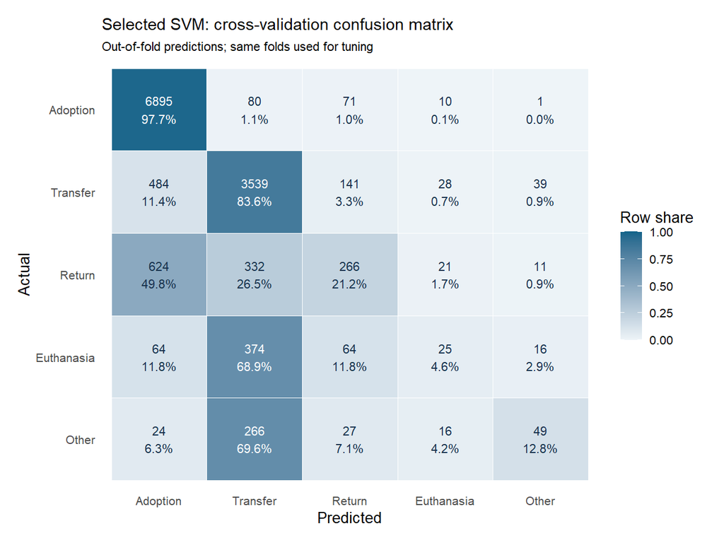